# A3: SPL Library Checkouts

### Introduction

The data is recording different reading materials with different usage type like physical or digital. The trend I would like to analyze is the checkouts trend of digital, specifically Ebooks. The reason for choosing this topic is I want to see when we entering the period of internet and smart devices, how people selecting between the normal physical copies of books or they are more welling to follow the time trend, that is, more likely to pick the electronic version of reading materials online. From this data set, I will be likely find put the trends of how people selecting their form of reading materials as the world is developing.

### Summary Information

From the calculation I did, I find that “So You Want to Talk about Race (Unabridged)” is the digital book with the most monthly checkout amount(4903), and the book “Headphones / Seattle Public Library.” is the physical book with the most monthly checkout amount(2115). Also, in 2017, the book with the most monthly checkout amount(988) is “In Building Device Checkout”. Besides that, my favorite album “24K Magic” has a highest checkout number at the year 2017. Last but not least, I find a increase trend of Ebooks checkout number over the checkout year until the year 2020, but in the year 2023, the number has a sudden decrease which might due to the data include checkouts only for the first two month of the year.

### The Dataset

The data was collected by Seattle Public Library, the parameters in this dataset include Usage Class, Checkout Type, Material Type, Checkout Year, Checkout Month, Checkouts, Title, ISBN, Creator, Subjects, Publisher, Publication Year. The digital checkout data is from various media vendors, the physical data is from The Legrady artwork data archives. The data was collected for checking the trends of checkouts of different book in different sources like physical and digital. The ethical question that might be facing is what the book’s audiences is. When dealing with this, we need to be patient and reflecting the result using words that do not hurt their feelings.

The possible limitations with this data is there are many missing values that might be important when finding the trends that we needed. The missing value might form a false trend when we analyzing the data. Also the format of some variables are not the same, this cause a problem when we try to analyze the data that include the associated “untidy” data. We might need some time find a best way to clean up the data set before we start finding data visualization. Last but not least, we need to focus the category of the book, the physical and digital have different patterns and we need to be aware of what the observations belong to.

### First Trends Over Time Chart

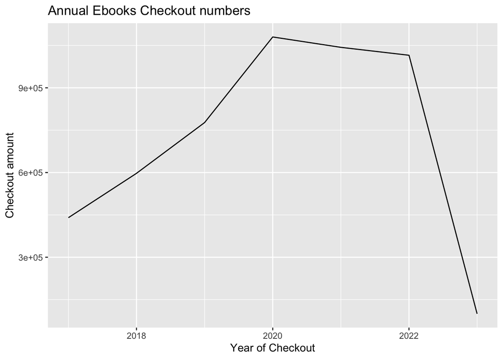

This chart is aimed to check whether there is a increasing trend of the Ebooks checkout number in the dataset. The real condition seems to be a little bit different from what I thought, it is true that there is a increase from 2017 to 2020, but there is a slight decrease from 2020 to 2022, and a sudden decrease at 2023. This might due to the record is stopped at Feb 2023.

### Second Trends Over Time Chart

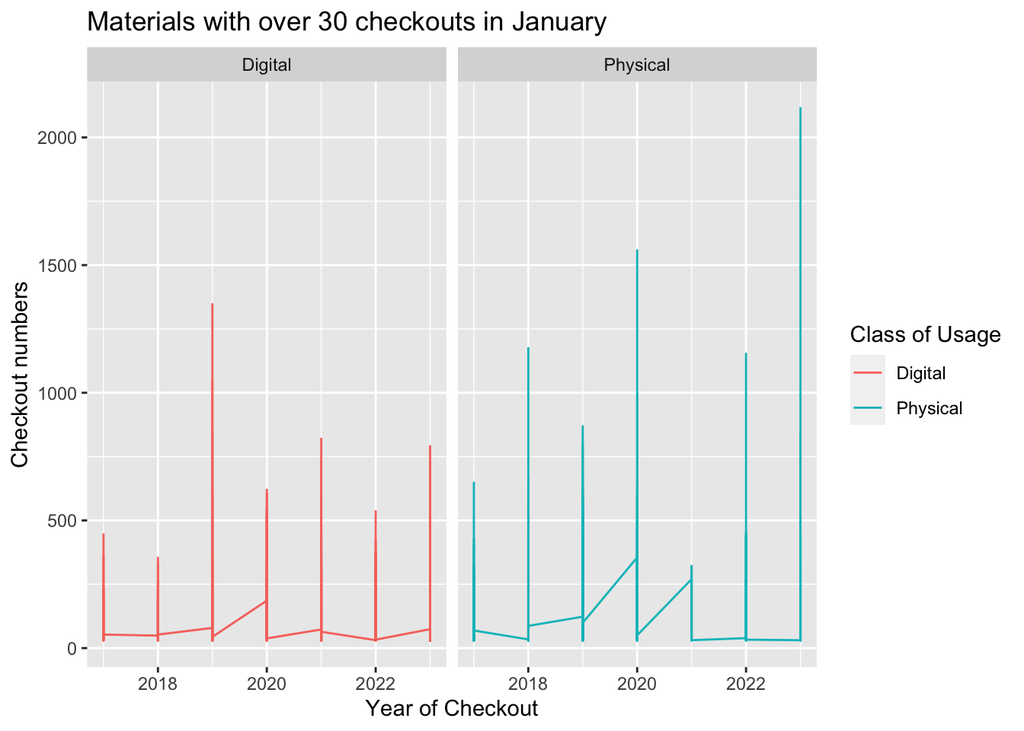

### Your Choice

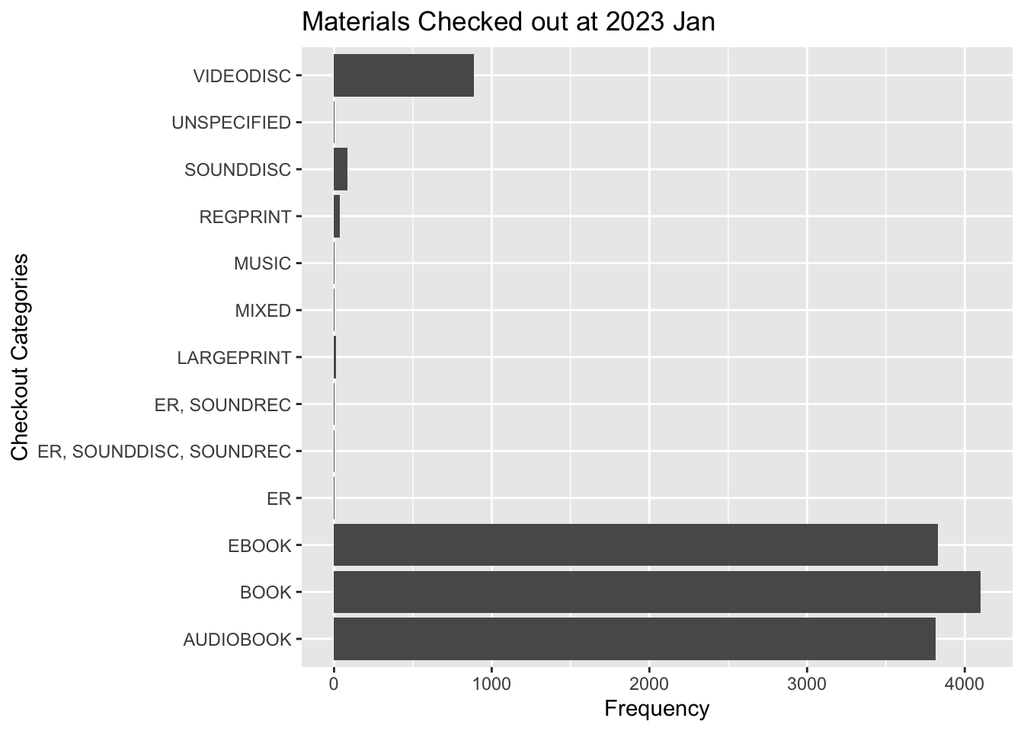

This chart is aimed to see which type of material is welcomed by the customers to checkout in the Jan of 2023, the result is books, E-books, and audio books. This is interesting since in the year of 2023 people still seems are more comfortable reading or listening to something that is a paper book or something that is closest to the form of book. This might because people are still have the largest possibility getting access to these form of reading materials, or to say, other forms are less well-known or harder to become prevalent in the society. Things like video disc and sound disc, they are out of time but still aged and old-fashioned people are more likely to keep them and still checking out them from the store.